# RNA-seq数据通路富集分析

分子细胞科学卓越创新中心生物信息平台

9 June 2020

#### Abstract

本文描述了bulk RNA-seq分析流程中通路富集子模块，该模块可以得到样本的GO、Pathway富集结果，可以用来评估样本的通路富集情况。该模块用R语言编写。

# 1 分析流程示意图

该模块需要输入差异基因列表，分别得到上下调基因的GO、Pathway富集结果。当GO term 数量大于50时，我们会对GO term 用“binaray_cut”<sup>1</sup>方法将功能相近的条目归为一类，然后给出GO term 的相似性热图，否则会直接给出富集气泡图，并且给出富集的表格；KEGG 通路富集结果则给出富集气泡图和表格，如下图所示。

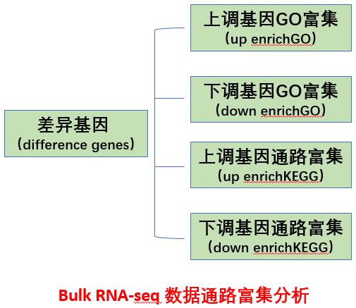

# 2 输出

## 2.1 GO term 富集图

本流程使用R包clusterProfiler<sup>2</sup>来完成GO富集，上下调基因分别进行从 MF（Molecular Function）、BP（Biological Process）、 CC（Cellular Component）这三个层面富集，从而得到差异基因显著富集的 GO 分类，这里以BP富集结果来展示，如下图所示。

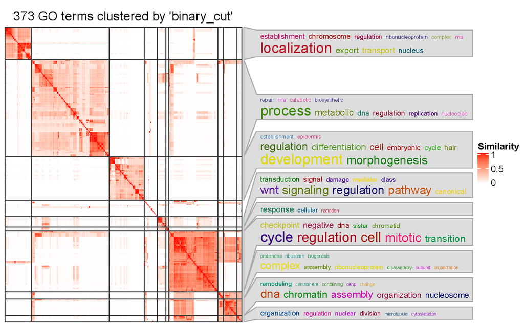

注：  
文件名说明：例如Treat_vs_Control_UP_BP_GO_simplified.pdf，“Treat_vs_Control”表示差异分组信息，“UP”表示上调基因，“BP”表示GO的生物过程，“simplified”表示相似性简化的GO热图。

## 2.2 GO term 表格

| ID | Description | GeneRatio | BgRatio | pvalue | p.adjust | qvalue | geneID | Count |
| --- | --- | --- | --- | --- | --- | --- | --- | --- |
| GO:0002250 | adaptive immune response | 217/3253 | 412/18188 | 0 | 0 | 0 | CD79B/MASP2/CD4/BTK/FYN/CD6/WAS/SLC11A1/CD74/C8B/SLAMF7/BTN3…… | 217 |
| GO:0050900 | leukocyte migration | 203/3253 | 437/18188 | 0 | 0 | 0 | ITGAL/ITGA3/FYN/CD74/DAPK2/STAP1/KITLG/CD84/RHOA/ROCK1/STK10…… | 203 |
| GO:0042110 | T cell activation | 200/3253 | 463/18188 | 0 | 0 | 0 | ITGAL/CD4/FYN/CD6/WAS/IGF1/SLC11A1/CD74/BTN3A1/TNFRSF1B/PRKC…… | 200 |
| GO:0002697 | regulation of immune effector process | 178/3253 | 401/18188 | 0 | 0 | 0 | FGR/CFH/PGLYRP1/BTK/TYROBP/CD22/WAS/CD74/C8B/BIRC3/TNFRSF1B/…… | 178 |
| GO:0042119 | neutrophil activation | 203/3253 | 496/18188 | 0 | 0 | 0 | FGR/ENPP4/MPO/ITGAL/ALDH3B1/PGLYRP1/MMP25/PLAUR/TYROBP/LTF/A…… | 203 |

注：  
文件名说明：例如Treat_vs_Control_BP_UP_GO.txt，“Treat_vs_Control”表示差异分组信息，“UP”表示上调基因，“BP”表示GO的生物过程。  
ID：Gene Ontology数据库中GO条目的ID；  
Description：Gene Ontology 条目的功能描述信息；  
GeneRatio：前面是富集到该GO条目的基因数，后面是差异基因数；  
BgRatio：前面是该GO条目的总数，后面是该物种的基因总数；  
pvalue：富集分析统计学显著水平；  
p.adjust：多重假设检验校正后的p值;  
qvalue：对p值进行统计学检验后的q值；  
geneID：基因的Symbel ID；  
Count：富集到该GO条目的基因数。

## 2.3 Pathway 富集气泡图

Pathway富集分析同样使用R包clusterProfiler来完成，当富集到的pathway数量较多时，展示前30个通路，否则展示全部通路，如下图所示：

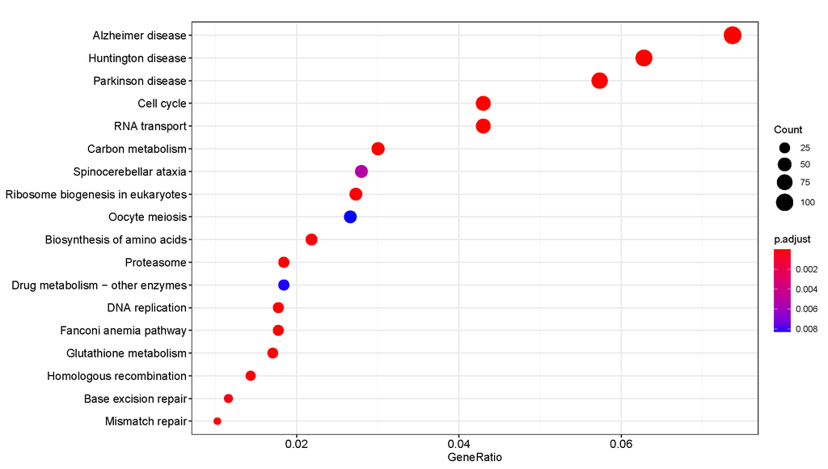

注：  
文件名说明：例如Treat_vs_Control_UP_KEGG_dotplot.pdf，“Treat_vs_Control”表示差异分组信息，“UP”表示上调基因，“KEGG_dotplot”表示Pathway富集气泡图。

## 2.4 Pathway 表格

| ID | Description | GeneRatio | BgRatio | pvalue | p.adjust | qvalue | geneID | Count |
| --- | --- | --- | --- | --- | --- | --- | --- | --- |
| hsa04110 | Cell cycle | 63/1465 | 124/7984 | 0 | 0e+00 | 0.0e+00 | CDC27/DBF4/E2F2/SMC1A/MCM2/MCM6/SMC1B/RBL1/ORC1/ORC6/CDC45/C…… | 63 |
| hsa03030 | DNA replication | 26/1465 | 36/7984 | 0 | 0e+00 | 0.0e+00 | POLA2/RFC2/POLD1/MCM2/MCM6/MCM5/POLE2/MCM4/RNASEH2A/LIG1/SSBP1/RPA3/POLD2/RFC5/MCM3/RPA1/PCNA/RFC3/DNA2/PRIM2/POLE3/RFC4/MCM7/FEN1/POLE/PRIM1 | 26 |
| hsa03050 | Proteasome | 27/1465 | 46/7984 | 0 | 1e-07 | 1.0e-07 | PSMB1/PSMC4/PSMA4/PSME4/PSMC5/PSMC1/PSMB5/PSMA6/PSMA7/PSMD7/PSMA2/PSMD3/PSMD11/PSMD14/SEM1/PSMA1/ADRM1/PSME3/POMP/PSMB7/PSMD4/PSMB4/PSMC2/PSMC3/PSMD2/PSMD12/PSMB3 | 27 |
| hsa05012 | Parkinson disease | 84/1465 | 249/7984 | 0 | 2e-07 | 2.0e-07 | NDUFAB1/SLC25A5/PSMB1/PSMC4/PSMA4/HSPA5/NDUFB4/SDHA/VDAC3/PS…… | 84 |
| hsa03013 | RNA transport | 63/1465 | 179/7984 | 0 | 3e-06 | 2.7e-06 | ELAC2/TACC3/THOC3/NDC1/PABPC1/CLNS1A/NUP37/THOC1/XPO1/SEH1L/…… | 63 |

# 3 参考文献

- [1] Zuguang Gu (2020). simplifyEnrichment: Simplify Functional Enrichment Results. https://github.com/jokergoo/simplifyEnrichment.
- [2] Yu G , Wang L G , Han Y , et al. clusterProfiler: an R Package for Comparing Biological Themes Among Gene Clusters[J]. Omics A Journal of Integrative Biology, 2012, 16(5):284-287.